# Text Analysis Demo

15-02-2022

## Today’s schedule

1. Install required software
2. Read data into R
3. Convert R data to quanteda format
4. Text Analysis with quanteda: Descriptive statistics
5. Text Analysis with quanteda: Estimating models
6. Estimating Glove

## Required software

- R, RStudio
- r-packages
  - tidyverse
  - quanteda (https://quanteda.io/articles/pkgdown/quickstart_ja.html)
    - quanteda.textmodels
    - quanteda.textstats
    - quanteda.textplots
  - caret (machine learning utility)
  - e1071 (confusionMatrix function)
  - text2vec (word embedding)
  - stringi (general text processing)

## Download data and slides

- All the files used in this workshop are compiled in this github repository https://github.com/amatsuo/HEROES-2022-TextAnalysis
- In RStudio, click on the project icon
  - New Project]->[Version Control]->[Git]
  - Enter the URL above

## Packages

1. tidyverse
   - https://www.tidyverse.org/
   - “The tidyverse is an opinionated collection of R packages designed for data science.”
   - To install

   ```r
   install.packages("tidyverse")
   ```

2. quanteda
   - R package for integrated text analysis
   - To install

   ```r
   install.packages("quanteda", "quanteda.textplots", "quanteda.textmodels",
                    "quanteda.textstats")
   ```

3. other

   ```r
   install.packages(c("caret", "e1071", "DT", "text2vec", "stringi"))
   ```

## Load text data into R

**Load the packages**

```r
library(tidyverse)
```

```r
library(quanteda)
library(quanteda.textmodels)
library(quanteda.textstats)
library(quanteda.textplots)
library(stringi)
library(caret)
library(DT)
```

## Load text data into R

- All the data is in the `data` folder
- This is the IMF and AMRO country reports extracted from pdf

**Let’s list the files first**

```r
list.files("data", pattern = "csv")
```

```
##  [1] "AMRO-Indonesia-2018.csv" "AMRO-Japan-2018.csv"
##  [3] "AMRO-Korea-2018.csv"     "AMRO-Thailand-2018.csv"
##  [5] "AMRO-Vietnum-2017.csv"   "IMF-Indonesia-2018.csv"
##  [7] "IMF-Indonesia-2019.csv"  "IMF-Japan-2018.csv"
##  [9] "IMF-Korea-2018.csv"      "IMF-Thailand-2018.csv"
## [11] "IMF-Vietnum-2018.csv"
```

- 11 files, file name with the convention `{InternationalOrganization}-{Country}-{year}.csv`

## Load text data into R

### Check the contents of the file

```r
data_temp <- read_csv("data/AMRO-Korea-2018.csv") # Open the data
print(data_temp) # Print it to the screen
```

```
## # A tibble: 1,514 × 5
##    page_number paragraph_number text                     pages_to_skip detection
##          <dbl>            <dbl> <chr>                    <lgl>         <chr>
##  1           1                1 <NA>                     TRUE          empty
##  2           1                2 <NA>                     TRUE          empty
##  3           1                3 ASEAN+3 Macroeconomic R… TRUE          page_foo…
##  4           1                4 <NA>                     TRUE          empty
##  5           1                5 <NA>                     TRUE          empty
##  6           1                6 AMRO Annual Consultatio… TRUE          normal
##  7           1                7 Korea - 2018             TRUE          normal
##  8           1                8 <NA>                     TRUE          empty
##  9           1                9 <NA>                     TRUE          empty
## 10           1               10 <NA>                     TRUE          empty
## # … with 1,504 more rows
```

The pre-processed pdfs of the report are in their respective files. From here, we can remove the unnecessary rows and columns and extract the necessary variables

## Load text data into R

### Data Processing

- Variables to use are `page_number, paragraph_number, text`.
- To delete a line, use the value of the variable `pages_to_skip, detection`.

**Processing dataframes with `dplyr`**.

```r
# Comments after "#".

data_temp <- data_temp %>% # "%>%" is dplyr's pipe
  filter(pages_to_skip != TRUE) %>% # filter rows. Remove pages to skip.
  filter(detection == "normal") %>% # select lines with normal text
  select(page_number, paragraph_number, text)
print(data_temp)
```

```
## # A tibble: 564 × 3
##    page_number paragraph_number text
##          <dbl>            <dbl> <chr>
##  1           4                4 Executive Summary
##  2           4                5 1. Korea’s economy is expected to grow at poten…
##  3           4                6 2. Headline inflation eased from 1.9 percent in…
##  4           4                7 3. The economy is resilient to external shocks …
##  5           4                8 4. The monetary policy stance remains accommoda…
##  6           4                9 5. In 2018, fiscal policy has been expansionary…
##  7           4               10 6. Weaker-than-expected growth in China and the…
##  8           4               11 7. Risks and vulnerability stemming from high h…
##  9           5                4 risk from the debt build-up is not a concern, g…
## 10           5                5 8. Although the external sector remains very st…
## # … with 554 more rows
```

## Load text data into R

### Batch processing of many files

Putting all these processes together into a single data frame Here are three ways to do it

##### Method 1: Use a for loop (don’t)

```r
data_all <- NULL # create empty data
file_names <- list.files("data", pattern = "csv", full.names = TRUE)

for (fn in file_names) {
  data_current <- read_csv(fn) # open a file
  data_current <- data_current %>%
    filter(pages_to_skip != TRUE) %>%
    filter(detection == "normal") %>%
    select(page_number, paragraph_number, text) %>%
    mutate(file_name = fn)
  data_all <- bind_rows(data_all, data_current)
}
```

## Load text data into R

##### Method 2: map() + bind_rows() (or map_dfr())

```r
file_names <- list.files("data", pattern = "csv", full.names = TRUE)

data_all_2 <- file_names %>%
  map(~read_csv(.x) %>%
    filter(pages_to_skip != TRUE) %>%
    filter(detection == "normal") %>%
    select(page_number, paragraph_number, text) %>%
    mutate(file_name = .x)) %>% bind_rows()
```

## Load text data into R

### Method 3: use `readtext`

```r
library(readtext)
data_all_3 <-
  readtext("data", text_field = "text") %>%
  filter(pages_to_skip != TRUE) %>%
  filter(detection == "normal") %>%
  select(doc_id, page_number, paragraph_number, text) %>%
  rename(file_name = doc_id)
```

## Load text data into R

#### Extracting variables from file names

Since the data we have created so far does not contain country names, etc., we will extract them from the variables in the file name.

```r
data_all <-
  data_all %>%
  # Create tmp temporary variable
  mutate(tmp = file_name %>%
           stri_replace_first_fixed("data/", "") %>%
           stri_replace_first_fixed(".csv", "")) %>% # remove extraneous parts
  separate(tmp, sep = "-", into = c("institution", "country", "year"))
　# Use dplyr's separate() to split the tmp column into three variables
```

## Convert R data to quanteda format

With quanteda, you can easily convert R data frames into a form that can be used for data analysis.

**Steps**.

1. Create a corpus
2. Tokenize the text
3. Create a document feature matrix (DFM)

## Creating a corpus

A **corpus** is an object of **quanteda** that stores texts and a set of meta-variables of the text together, and can be easily created from an R dataframe. The texts are usually not modified before the corpus is created, but the corpus of paragraphs can be divided into sentences at this stage.

```r
data_corpus <- corpus(data_all, text_field = "text")
print(data_corpus)
```

```
## Corpus consisting of 6,041 documents and 6 docvars.
## text1 :
## "Executive Summary The Indonesian economy has been resilient ..."
##
## text2 :
## "2. Inflation is expected to be contained within Bank Indones..."
##
## text3 :
## "3. The current account deficit is expected to widen in 2018,..."
##
## text4 :
## "4. Reflecting risk aversion towards emerging markets (EMs) s..."
##
## text5 :
## "5. The official foreign reserves declined in early 2018 but ..."
##
## text6 :
## "6. The banking sector has maintained strong capital buffer w..."
##
## [ reached max_ndoc ... 6,035 more documents ]
```

Use `as.character()` to check the contents

```r
as.character(data_corpus) %>% head(2) %>% print()
```

```
##                                                                                                                                                                                                                                                                                                          …
## "Executive Summary The Indonesian economy has been resilient against external headwinds, as growth is expected to remain robust and inflation contained in 2018. Recent policy mix recalibration with the implementation of “pre-emptive, front-loading, and ahead-of-the-curve” measures have focused on…
##                                                                                                                                                                                                                                                                                                          …
##                                                                                                                                                                                                                                                                                                          …
```

### Extracting document variables

A corpus created from a dataframe with `corpus()` retains all variables, and they are inherited even if you tokenize or create a dfm. Use the `docvars()` command to extract them.

```r
docvars(data_corpus) %>% head()
```

```
##   page_number paragraph_number                    file_name institution
## 1           4                5 data/AMRO-Indonesia-2018.csv        AMRO
## 2           4                6 data/AMRO-Indonesia-2018.csv        AMRO
## 3           4                7 data/AMRO-Indonesia-2018.csv        AMRO
## 4           4                8 data/AMRO-Indonesia-2018.csv        AMRO
## 5           4                9 data/AMRO-Indonesia-2018.csv        AMRO
## 6           4               10 data/AMRO-Indonesia-2018.csv        AMRO
##     country year
## 1 Indonesia 2018
## 2 Indonesia 2018
## 3 Indonesia 2018
## 4 Indonesia 2018
## 5 Indonesia 2018
## 6 Indonesia 2018
```

## Corpus Transformation

`quanteda` provides a method for remaking a corpus in the form of `corpus_*()`.

#### Changing text units

From paragraphs to sentence units.

```r
data_corpus_sentence <- corpus_reshape(data_corpus, to = 'sentences')
print(data_corpus_sentence)
```

```
## Corpus consisting of 14,609 documents and 6 docvars.
## text1.1 :
## "Executive Summary The Indonesian economy has been resilient ..."
##
## text1.2 :
## "Recent policy mix recalibration with the implementation of “..."
##
## text1.3 :
## "Continued pro-active policy mix recalibration is hence recom..."
##
## text1.4 :
## "1."
##
## text1.5 :
## "Indonesia’s economic fundamentals remain robust with growth ..."
##
## text1.6 :
## "Real GDP grew at 5.1 percent in 2017, led by public investme..."
##
## [ reached max_ndoc ... 14,603 more documents ]
```

#### Selecting part of a corpus

The second argument of `corpus_subset()` specifies the condition for selecting a corpus. You can use document variables directly.

```r
data_corpus_korea <- corpus_subset(data_corpus, country == 'Korea')
print(data_corpus_korea)
```

```
## Corpus consisting of 1,499 documents and 6 docvars.
## text567 :
## "Executive Summary"
##
## text568 :
## "1. Korea’s economy is expected to grow at potential. The eco..."
##
## text569 :
## "2. Headline inflation eased from 1.9 percent in 2017 to 1.4 ..."
##
## text570 :
## "3. The economy is resilient to external shocks on the back o..."
##
## text571 :
## "4. The monetary policy stance remains accommodative with the..."
##
## text572 :
## "5. In 2018, fiscal policy has been expansionary in support o..."
##
## [ reached max_ndoc ... 1,493 more documents ]
```

## Tokenization

**quanetda** uses the `tokens()` command to tokenize text. There are various units of tokens, but usually words are used as a unit.

```r
data_tokens <- tokens(data_corpus)
data_tokens[1]
```

```
## Tokens consisting of 1 document and 6 docvars.
## text1 :
##  [1] "Executive"  "Summary"    "The"        "Indonesian" "economy"
##  [6] "has"        "been"       "resilient"  "against"    "external"
## [11] "headwinds"  ","
## [ ... and 159 more ]
```

## Removing unnecessary tokens, reshaping tokens

In the process of creating a `tokens()` object, or after it has been created, you can format the tokens as needed.

All options are basically turned off by default, but you can turn them on to perform various operations.

```r
tokens_temp <- tokens(data_corpus,
                      remove_numbers = FALSE,
                      remove_punct = FALSE,
                      remove_symbols = FALSE,
                      remove_separators = TRUE,
                      remove_twitter = FALSE,
                      remove_hyphens = FALSE,
                      remove_url = FALSE)
```

Or you can use `tokens_select()` for more fine-grained operations.

```r
long_tokens <- tokens_select(data_tokens, min_nchar = 3)
number_tokens <- tokens_select(data_tokens, "^\\d", valuetype = "regex")
```

## KeyWord-In-Context (kwic)

By applying kwic to **tokens** objects, you can extract the contexts in which words of interest to you are used. For example, “inflation targeting”.

```r
kwic(data_tokens, phrase("inflation targe*"))
```

```
## Keyword-in-context with 68 matches.
##     [text256, 16:17]                   Bank of Japan's 2 percent |
##     [text326, 36:37]              achievability of the 2 percent |
##     [text326, 85:86]               over the achievability of the |
##     [text328, 84:85]                   for the current 2 percent |
##     [text329, 60:61]  strengthening commitments to achieving the |
##   [text477, 123:124]          investigating the optimal level of |
##     [text478, 23:24]              achievability of the 2 percent |
##     [text596, 17:18] ) Headline inflation Inflation expectations |
##       [text781, 1:2]                                             |
##    [text1165, 31:32]               , below the BOT's medium-term |
##  [text1165, 181:182]               months falls within the BOT's |
##    [text1257, 26:27]                     moving in line with the |
##    [text1284, 15:16]            has been below BOT's medium-term |
##    [text1702, 73:74]                    to the attainment of the |
##  [text2019, 101:102]                   to the achievement of the |
##    [text2153, 58:59]                         adopted in 2003. An |
##  [text2582, 128:129]            patient approach to reaching the |
##    [text2583, 83:84]            public support for achieving the |
##  [text2583, 101:102]                interest rate target and the |
##  [text2583, 137:138]      consider moving closer to full-fledged |
##      [text2592, 1:2]                                             |
##     [text2598, 9:10]          BoJ acknowledged that reaching the |
##    [text2704, 52:53]            patient approach to reaching the |
##    [text2704, 73:74]                interest rate target and the |
##  [text2704, 105:106]                   closer to a full- fledged |
##      [text2877, 1:2]                                             |
##    [text3364, 27:28] Inflation expectations re-anchored at BoJ's |
##      [text3767, 8:9]         MONETARY POLICY FRAMEWORK IN KOREA1 |
##    [text3767, 38:39]       inflation expectations fell below the |
##      [text3768, 6:7]                          1. The adoption of |
##    [text3768, 60:61]                          crisis ( GFC ) put |
##    [text3768, 81:82]                       the 2.5 - 3.5 percent |
##  [text3768, 102:103]                     was replaced by a level |
##      [text3769, 7:8]                      . The reduction in the |
##    [text3769, 58:59]               a reassessment of the optimal |
##     [text3776, 9:10]             measure of the effectiveness of |
##      [text3777, 3:4]                                          4. |
##  [text3777, 104:105]              incentives to deviate from the |
##    [text3778, 11:12]        environment revealed areas where the |
```

[output cut: 83 more lines]

```
##   Inflation target   | Core inflation, Feb-2018 (
##   Inflation Target   | and Core Inflation ( Percent
##   inflation target   | , with macroprudential policy used
##   inflation target   | , while addressing financial stability
##   inflation target   | . Thailand: Financial Soundness
##   inflation target   | while using macroprudential policy to
##   inflation target   | . A flexible exchange rate
##  inflation targeting | framework, especially the need
##   inflation target   | and limiting financial vulnerabilities.
##   inflation target   | should be done flexibly,
##  inflation targeting | .
##  inflation targeting | . Banks must be strengthened
##  inflation targeting | and greater exchange rate flexibility
##  inflation targeting | , but the sequencing of
##  inflation targeting | and greater exchange rate flexibility
```

## Create a tokens object for the purpose of this analysis

```r
data_tokens_final <- tokens(data_corpus,
                      remove_numbers = TRUE,
                      remove_punct = FALSE,
                      remove_symbols = FALSE,
                      remove_separators = TRUE,
                      split_hyphens = FALSE,
                      remove_url = TRUE) %>%
  tokens_remove(pattern = stopwords(), padding = TRUE) %>% # remove stopwords
  tokens_remove(pattern = c("AMRO", "IMF"), padding = TRUE) %>% # remove institution name
  tokens_remove(pattern = c("Indonesia*", "Japan*", "Korea*", "Thai*", "Vietnum*"),
                padding = TRUE) %>% # remove country names
  tokens_keep(pattern = "^[a-zA-Z]+$", valuetype = "regex", padding = TRUE) # Keep words made of only alphabetic characters

data_tokens_final[1]
```

```
## Tokens consisting of 1 document and 6 docvars.
## text1 :
##  [1] "Executive" "Summary"   ""          ""          "economy"   ""
##  [7] ""          "resilient" ""          "external"  "headwinds" ""
## [ ... and 148 more ]
```

## Find the collocation

Try calculating the collocation

```r
colloc <- textstat_collocations(data_tokens_final, min_count = 5, tolower = FALSE)
colloc %>%
  filter(collocation %>% stri_trans_tolower %>% stri_detect_fixed("inflation"))
```

```
##                 collocation count count_nested length    lambda          z
## 23   inflation expectations    83            0      2 6.9248874 37.5007570
## 67         inflation target    44            0      2 4.9515257 28.4763889
## 165           CPI inflation    26            0      2 5.5019366 23.0709206
## 234       Inflation Primary    15            0      2 6.3130239 21.1746209
## 356      Headline inflation    17            0      2 5.7535562 18.8618954
## 388      headline inflation    21            0      2 7.0005351 18.4626740
## 398          core inflation    16            0      2 5.4527349 18.2494878
## 408           low inflation    24            0      2 3.9135967 18.1205191
## 426   inflationary pressure    10            0      2 9.4592473 17.9102707
## 471         price inflation    18            0      2 4.4035277 17.3573717
## 482     inflation targeting    14            0      2 5.7492475 17.1957821
## 556          Core inflation    13            0      2 5.8500682 16.5567979
## 623        actual inflation    12            0      2 5.7234912 15.9666419
## 665     Inflation Inflation    10            0      2 5.2596420 15.7261815
```

[output cut: 22 more lines]

## “stability”

```r
colloc %>%
  filter(collocation %>% stri_trans_tolower %>% stri_detect_fixed("stability"))
```

```
##                   collocation count count_nested length   lambda         z
## 13        financial stability   105            0      2 5.860390 41.147339
## 182           price stability    21            0      2 5.547400 22.590181
## 299   macroeconomic stability    16            0      2 5.563074 20.007447
## 763       Financial Stability    14            0      2 8.207349 15.098825
## 963          stability target    11            0      2 4.291900 13.798348
## 1007 macrofinancial stability     7            0      2 7.318026 13.540361
## 1167       stability concerns     6            0      2 5.395953 12.554230
## 1559         system stability     7            0      2 3.908451 10.323352
## 1717       external stability     8            0      2 3.248732  9.192433
## 1815          stability risks     6            0      2 3.333536  8.280456
```

## Use of collocation

There are many possible ways to use this, but one way is to concatenate a collocation and use this in subsequent analysis.

```r
colloc <- colloc %>% filter(z > 3)
data_tokens_compounded <- tokens_compound(data_tokens_final,
                                          pattern = phrase(colloc$collocation)) %>%
  tokens_remove("*consultation_report*")
```

## Create a dfm

Using the tokens object created so far, create a document feature matrix (dfm) for later analysis. A dfm is a matrix where each document is a row and each feature (e.g. word) is a column.

```r
data_dfm <- dfm(data_tokens_compounded, tolower = TRUE) %>%
  dfm_select(min_nchar = 3) # Remove words with less than 3 characters.
data_dfm
```

```
## Document-feature matrix of: 6,041 documents, 10,271 features (99.84% sparse) and 6 docvars.
##        features
## docs    executive summary economy resilient external headwinds growth expected
##   text1         0       0       1         1        0         0      2        2
##   text2         0       0       0         0        0         0      0        1
##   text3         0       0       0         0        0         0      0        1
##   text4         0       0       0         0        0         0      1        0
##   text5         0       0       0         0        0         0      0        0
##   text6         0       0       0         0        0         0      0        0
##        features
## docs    remain robust
##   text1      2      2
##   text2      0      0
##   text3      0      0
##   text4      0      0
##   text5      1      0
##   text6      1      0
## [ reached max_ndoc ... 6,035 more documents, reached max_nfeat ... 10,261 more features ]
```

Furthermore, erase words that only appear in one document or that have not been used more than 10 times.

```r
data_dfm <- dfm_trim(data_dfm, min_docfreq = 2, min_termfreq = 10)
data_dfm
```

```
## Document-feature matrix of: 6,041 documents, 2,479 features (99.49% sparse) and 6 docvars.
##        features
## docs    summary economy resilient external growth expected remain robust
##   text1       0       1         1        0      2        2      2      2
##   text2       0       0         0        0      0        1      0      0
##   text3       0       0         0        0      0        1      0      0
##   text4       0       0         0        0      1        0      0      0
##   text5       0       0         0        0      0        0      1      0
##   text6       0       0         0        0      0        0      1      0
##        features
## docs    inflation contained
##   text1         1         1
##   text2         3         2
##   text3         0         0
##   text4         0         0
##   text5         0         0
##   text6         0         0
## [ reached max_ndoc ... 6,035 more documents, reached max_nfeat ... 2,469 more features ]
```

## Text analysis with quanteda: Descriptive statistics

## Competing expectations

**1. (globalist complementarity): AMRO is as neoclassical as IMF**

**2. (developmental state hypothesis): AMRO is more developmentalist than IMF**

## Commonly used words

First, let’s simply check what words are used.

```r
topfeatures(data_dfm, n = 30)
```

```
##            percent                gdp        authorities             figure
##               2165                835                470                455
##               also             source             growth           increase
##                447                442                419                407
##          including            sources              banks               data
##                394                336                297                295
##         investment         employment            vietnam             higher
##                282                275                273                260
##              total            economy             policy          inflation
##                258                252                252                245
##               bank            exports           measures               debt
##                245                235                234                233
## staff_calculations             impact          increased              since
##                229                226                225                225
##           expected              risks
##                224                224
```

## Check keyness

Use `textstat_keyness()` to compare the difference between feature words used in AMRO and IMF.

### Keywords for AMRO

```r
textstat_keyness(data_dfm, target = docvars(data_dfm, "institution") == "AMRO") %>% head(20)
```

```
##       feature      chi2            p n_target n_reference
## 1      figure 257.88099 0.000000e+00      326         129
## 2      source 148.22995 0.000000e+00      280         162
## 3         lgs 126.31604 0.000000e+00       70           0
## 4       china 120.13855 0.000000e+00      124          37
## 5   meanwhile 113.09151 0.000000e+00       76           7
## 6        note 108.83844 0.000000e+00      123          42
## 7    ministry 108.13600 0.000000e+00       95          21
## 8    trillion 105.99814 0.000000e+00       72           7
## 9        ceic 104.73960 0.000000e+00       73           8
## 10      annex  82.60167 0.000000e+00       62           9
## 11      asean  81.53686 0.000000e+00       69          14
## 12 industries  76.50627 0.000000e+00       66          14
## 13 mega_banks  75.76634 0.000000e+00       42           0
## 14   overseas  73.90827 0.000000e+00       63          13
## 15  according  72.13823 0.000000e+00       59          11
## 16     budget  66.00909 4.440892e-16       97          45
## 17       amid  52.03687 5.446754e-13       47          11
## 18    tourism  51.22204 8.248957e-13       63          24
## 19        yoy  50.91220 9.658940e-13       42           8
## 20    billion  50.21996 1.374456e-12       99          59
```

## Check keyness

### Keywords for IMF

```r
textstat_keyness(data_dfm, target = docvars(data_dfm, "institution") == "IMF") %>% head(20)
```

```
##                    feature     chi2            p n_target n_reference
## 1                    youth 50.90373 9.701129e-13      117           6
## 2                 republic 48.91535 2.672529e-12       97           2
## 3                     jfsa 47.73988 4.866885e-12       86           0
## 4               employment 41.51061 1.172331e-10      228          47
## 5                 baseline 41.22873 1.354178e-10      121          12
## 6                  reforms 40.44036 2.027102e-10      133          16
## 7              medium_term 35.33548 2.775299e-09       92           7
## 8                education 31.81135 1.698968e-08      122          18
## 9       structural_reforms 31.70102 1.798281e-08      131          21
## 10                   staff 31.38895 2.111796e-08      118          17
## 11               improving 27.97749 1.227347e-07      114          18
## 12                  shocks 27.22499 1.811027e-07       87          10
## 13                    oecd 26.18064 3.109247e-07      101          15
## 14                    proj 25.52408 4.368965e-07       46           0
## 15             sustainable 24.61593 6.997088e-07       53           2
## 16                  reform 24.30455 8.224456e-07       94          14
## 17            minimum_wage 23.73239 1.107037e-06       70           7
## 18                    mtrs 22.74847 1.846508e-06       41           0
## 19 article_iv_consultation 22.19339 2.465212e-06       40           0
## 20                 dollars 22.01529 2.704864e-06       56           4
```

## Check keyness: keywords derived from expectations

The following list of words were provided as words that might be related to each hypothesis. Let’s feed the words that we are interested in on the next page.

**Globalist Hypothesis:** equilibrium, inflation targeting, currency volatility, fiscal stability, credibility, output gap, balanced growth, safety net, market economy, macro-prudential, capital adequacy, competition, debt sustainability

**Regional-developmentalist Hypothesis:** autonomy, capital accumulation, currency appreciation, fiscal stimulus, strategy, output growth, dynamic growth, competitiveness, state control, saving, investment, concentration, current account surplus

## Check keyness

```r
textstat_keyness(data_dfm, target = docvars(data_dfm, "institution") == "AMRO") %>%
  mutate_at(.vars = 2:3, round, digits = 3) %>%
  datatable()
```

|  | feature | chi2 | p | n_target | n_reference |
| --- | --- | --- | --- | --- | --- |
| 1 | figure | 257.881 | 0 | 326 | 129 |
| 2 | source | 148.23 | 0 | 280 | 162 |
| 3 | lgs | 126.316 | 0 | 70 | 0 |
| 4 | china | 120.139 | 0 | 124 | 37 |
| 5 | meanwhile | 113.092 | 0 | 76 | 7 |
| 6 | note | 108.838 | 0 | 123 | 42 |
| 7 | ministry | 108.136 | 0 | 95 | 21 |
| 8 | trillion | 105.998 | 0 | 72 | 7 |
| 9 | ceic | 104.74 | 0 | 73 | 8 |
| 10 | annex | 82.602 | 0 | 62 | 9 |

[output cut: 2469 more lines]

## Text analysis with quanteda: analysis with models

## Overview

In the following, we explain how to use the `textmodel_*` functions provided by **quanteda.textmodel**.

It estimates and interprets the following two models:

1. naive bayes model
2. wordfish model

## Classify using the Naive Bayes Model

- Supervised learning model
- Linear model so we can check the score of each word

**This example**.

- “AMRO”, “IMF” labels are outputs.
- The unit of analysis is each paragraph of the report
- What to check
  - Is it possible to classify the words based on their use in the first place?
  - If so, what words are influencing it?
- To avoid overlearning problems, separate the data into train and test.

## Use Naive Bayes Model for classification

```r
# shuffle dfm
set.seed(20190924)
data_dfm <- dfm_sample(data_dfm)

# train-test split
train <- sample(nrow(data_dfm), size = nrow(data_dfm) * 0.7)
train <- seq(nrow(data_dfm)) %in% train

# split dfm
data_dfm_train <- dfm_subset(data_dfm, subset = train)
data_dfm_test <- dfm_subset(data_dfm, subset = !train)

# estimate the model
model_nb <- textmodel_nb(data_dfm_train, docvars(data_dfm_train, "institution") == "AMRO")
```

## Naive Bayes

```r
train_pred <- predict(model_nb)
train_truth <- docvars(data_dfm_train, "institution") == "AMRO"
table(train_pred, train_truth)
```

```
##           train_truth
## train_pred FALSE TRUE
##      FALSE  2635  175
##      TRUE    465  953
```

```r
test_pred <- predict(model_nb, newdata = data_dfm_test)
test_truth <- docvars(data_dfm_test, "institution") == "AMRO"
table(test_pred, test_truth)
```

```
##          test_truth
## test_pred FALSE TRUE
##     FALSE  1112   95
##     TRUE    228  378
```

## Naive Bayes, Train Confusion Matrix

```r
confusionMatrix(train_pred, factor(train_truth))
```

```
## Confusion Matrix and Statistics
##
##           Reference
## Prediction FALSE TRUE
##      FALSE  2635  175
##      TRUE    465  953
##
##                Accuracy : 0.8486
##                  95% CI : (0.8375, 0.8593)
##     No Information Rate : 0.7332
##     P-Value [Acc > NIR] : < 2.2e-16
##
##                   Kappa : 0.6423
##
##  Mcnemar's Test P-Value : < 2.2e-16
##
##             Sensitivity : 0.8500
##             Specificity : 0.8449
##          Pos Pred Value : 0.9377
##          Neg Pred Value : 0.6721
##              Prevalence : 0.7332
##          Detection Rate : 0.6232
##    Detection Prevalence : 0.6646
##       Balanced Accuracy : 0.8474
##
##        'Positive' Class : FALSE
##
```

## Naive Bayes, Test Confusion Matrix

```r
confusionMatrix(test_pred, factor(test_truth))
```

```
## Confusion Matrix and Statistics
##
##           Reference
## Prediction FALSE TRUE
##      FALSE  1112   95
##      TRUE    228  378
##
##                Accuracy : 0.8218
##                  95% CI : (0.8034, 0.8392)
##     No Information Rate : 0.7391
##     P-Value [Acc > NIR] : < 2.2e-16
##
##                   Kappa : 0.5766
##
##  Mcnemar's Test P-Value : 2.063e-13
##
##             Sensitivity : 0.8299
##             Specificity : 0.7992
##          Pos Pred Value : 0.9213
##          Neg Pred Value : 0.6238
##              Prevalence : 0.7391
##          Detection Rate : 0.6133
##    Detection Prevalence : 0.6657
##       Balanced Accuracy : 0.8145
##
##        'Positive' Class : FALSE
##
```

## Naive Bayes, checking for words

## Prepare word data

```r
coef_prob <- coefficients(model_nb)[, 2] %>% data.frame() %>%
  rename(prob1 = ".") %>% rownames_to_column() %>%
  mutate(count =  data_dfm_train %>% colSums())
```

## Naive Bayes, word table

```r
coef_prob %>%
  filter(nchar(rowname) >=2) %>%
  filter(count > quantile(count, .7)) %>% # keep top thirty words
  arrange(-prob1) %>% mutate(prob1 = round(prob1, 3)) %>%
  datatable()
```

|  | rowname | prob1 | count |
| --- | --- | --- | --- |
| 1 | percent | 0.022 | 1536 |
| 2 | figure | 0.009 | 321 |
| 3 | source | 0.008 | 321 |
| 4 | gdp | 0.007 | 596 |
| 5 | growth | 0.005 | 309 |
| 6 | also | 0.004 | 319 |
| 7 | economy | 0.004 | 192 |
| 8 | banks | 0.004 | 203 |
| 9 | exports | 0.004 | 167 |
| 10 | china | 0.004 | 115 |

[output cut: 697 more lines]

## Scaling with Wordfish

As an example of unsupervised learning, we estimate the wordfish model.

**This example**.

- Unit of analysis is the report level
- Estimate the position of the report
- Since this is unsupervised learning, you need to interpret the meaning of the axes by yourself.

## Scaling with Wordfish

```r
# Create a new document variable "report".
docvars(data_dfm, "report") <- paste(docvars(data_dfm, "institution"),
                                     docvars(data_dfm, "country"),
                                     docvars(data_dfm, "year"))
# Use report to aggregate dfm to report level
data_dfm_report <- dfm_group(data_dfm, groups = report)
# Estimate the model
model_wf <- textmodel_wordfish(data_dfm_report)
```

## Wordfish: plotting positions

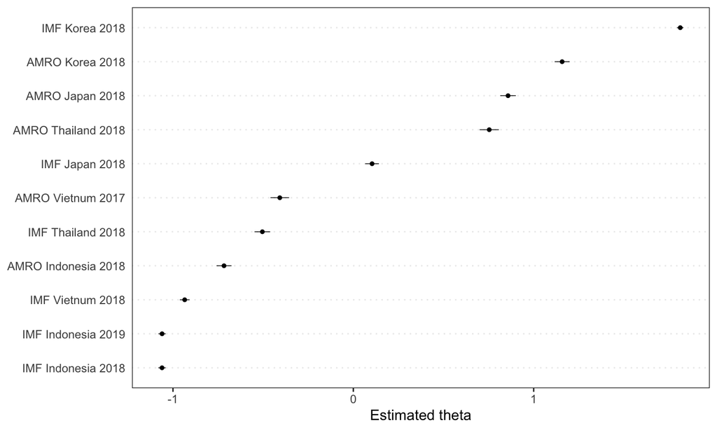

```r
textplot_scale1d(model_wf)
```

## Wordfish: plot words

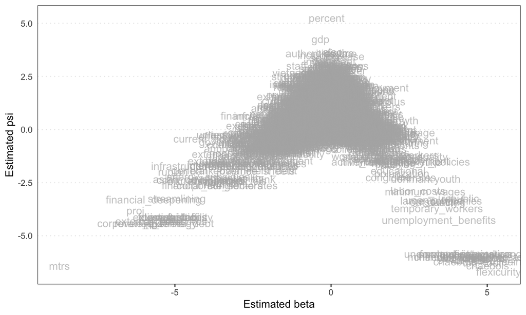

```r
textplot_scale1d(model_wf, margin = 'features')
```

## Wordfish: word table

```r
coefs <- coefficients(model_wf)$features %>%
  as.data.frame() %>% rownames_to_column(var = "feature") %>%
  mutate_at(2:3, round, digits = 3) %>% arrange(-beta)
datatable(coefs)
```

|  | feature | beta | psi |
| --- | --- | --- | --- |
| 1 | flexicurity | 5.368 | -6.694 |
| 2 | chaebols | 5.015 | -6.399 |
| 3 | top_four | 4.847 | -6.262 |
| 4 | chaebols_excluding | 4.785 | -6.212 |
| 5 | moel | 4.649 | -6.104 |
| 6 | college | 4.574 | -6.045 |
| 7 | orbis | 4.574 | -6.045 |
| 8 | top_chaebols | 4.574 | -6.045 |
| 9 | gvc_integration | 4.574 | -6.045 |
| 10 | banerji_et_al | 4.574 | -6.045 |

[output cut: 2469 more lines]

## Other things you can do with quanteda

- Estimating topic models
  - Use `convert()` function and fit a model
    - `topicmodels` and `stm`
- Estimating word vectors
  - `word2vec` (R package)
  - Or call python based packages through `reticulate`